# 1002126215

## INSTRUCTIONS

Every learner should submit his/her own homework solutions. However, you are allowed to discuss the homework with each other– but everyone must submit his/her own solution; you may not copy someone else’s solution.

The homework consists of one part:

1. Exploratory Data Analysis

Follow the prompts in the attached jupyter notebook. Download the data and place it in your working directory, or modify the path to upload it to your notebook. Add markdown cells to your analysis to include your solutions, comments, answers. $\color{red}{\text{Add as many cells as you need}}$, for easy readability comment when possible. Hopefully this homework will help you develop skills, makes you understand the flow of an EDA and get you ready for individual work.

**Submission: Send in both a ipynb and a html file of your work.**

Good luck!

# Exploratory Data Analysis (EDA)

Exploratory Data Analysis refers to the critical process of performing initial investigations on data so as to discover patterns,to spot anomalies,to test hypothesis and to check assumptions with the help of summary statistics and graphical representations.

This homework basically asks you to replicate the excersize posted on canvas for the iris dataset. Read the slides and check the code in the Iris_EDA.html file.The most important thing is to give some explanation every step of the way. You can only get full credit for the homework if we see your answers (spitting out code is not enough).

*Steps in EDA*:

1. Provide descriptions of your sample and features
2. Check for missing data
3. Identify the shape of your data
4. Identify significant correlations
5. Spot/deal with outliers in the dataset

These steps are a guidline. Play with graphs

$\color{red}{\text{Don't forget to add "markdown" cells to include your findings or to explain what you are doing}}$

```python
# importing packages
import numpy as np
from sklearn.datasets import load_iris
from sklearn import preprocessing
import pandas as pd
import seaborn as sns
import matplotlib.pyplot as plt
%matplotlib inline
```

```python
# Reading the CSV file
df_fish = pd.read_csv("Fish.csv")

# Printing top 5 rows
df_fish.head()
```

|  | Species | Weight | Length1 | Length2 | Length3 | Height | Width |
| --- | --- | --- | --- | --- | --- | --- | --- |
| 0 | Bream | 242.0 | 23.2 | 25.4 | 30.0 | 11.5200 | 4.0200 |
| 1 | Bream | 290.0 | 24.0 | 26.3 | 31.2 | 12.4800 | 4.3056 |
| 2 | Bream | 340.0 | 23.9 | 26.5 | 31.1 | 12.3778 | 4.6961 |
| 3 | Bream | 363.0 | 26.3 | 29.0 | 33.5 | 12.7300 | 4.4555 |
| 4 | Bream | 430.0 | 26.5 | 29.0 | 34.0 | 12.4440 | 5.1340 |

### 1. Provide descriptions of your sample and features

```python
df_fish.info()
print(df_fish.describe())
```

```
<class 'pandas.core.frame.DataFrame'>
RangeIndex: 159 entries, 0 to 158
Data columns (total 7 columns):
 #   Column   Non-Null Count  Dtype
---  ------   --------------  -----
 0   Species  159 non-null    object
 1   Weight   159 non-null    float64
 2   Length1  159 non-null    float64
 3   Length2  159 non-null    float64
 4   Length3  159 non-null    float64
 5   Height   159 non-null    float64
 6   Width    159 non-null    float64
dtypes: float64(6), object(1)
memory usage: 8.8+ KB
            Weight     Length1     Length2     Length3      Height       Width
count   159.000000  159.000000  159.000000  159.000000  159.000000  159.000000
mean    398.326415   26.247170   28.415723   31.227044    8.970994    4.417486
std     357.978317    9.996441   10.716328   11.610246    4.286208    1.685804
min       0.000000    7.500000    8.400000    8.800000    1.728400    1.047600
25%     120.000000   19.050000   21.000000   23.150000    5.944800    3.385650
50%     273.000000   25.200000   27.300000   29.400000    7.786000    4.248500
75%     650.000000   32.700000   35.500000   39.650000   12.365900    5.584500
max    1650.000000   59.000000   63.400000   68.000000   18.957000    8.142000
```

**Your Answer:**</strong>

1)there is only one value which is object and remaining values are float values 2)count is same for every column, and minimum weight is 0 so there is somthing wrong here

```python
df_fish.isnull().sum()
```

```
Species    0
Weight     0
Length1    0
Length2    0
Length3    0
Height     0
Width      0
dtype: int64
```

**Your Answer:**</strong>

there is no null values in df_fish data set

### 3. Identify the shape of your data

```python
df_fish.shape
```

```
(159, 7)
```

**What observations did you make?**</strong>

there are only 7 colums and 159 rows so data is organized with 7 features

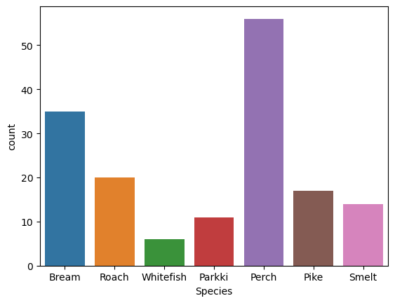

```python
import seaborn as sns
import matplotlib.pyplot as plt
%matplotlib inline


sns.countplot(x='Species', data=df_fish)
plt.show()
```

1) the perch is the most number of species of fish in the dataset 2) whitefish is the least number of species of fish in data set

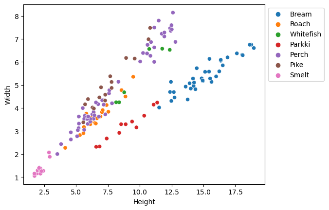

```python
sns.scatterplot(x='Height', y='Width',
                hue='Species', data=df_fish, )

# Placing Legend outside the Figure
plt.legend(bbox_to_anchor=(1, 1), loc=0)

plt.show()
```

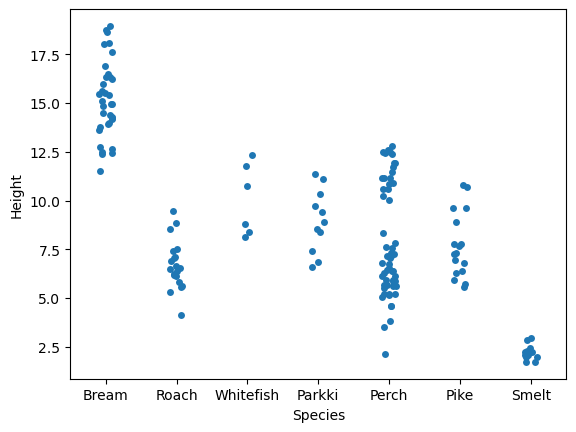

```python
sns.stripplot(y ='Height', x = 'Species', data = df_fish)
plt.show()
```

->bream species of fish are largest amoung the fishes and smelt is smallest

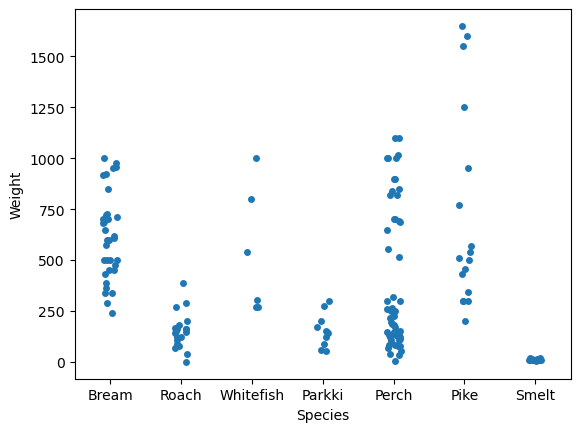

```python
sns.stripplot(y ='Weight', x = 'Species', data = df_fish)
plt.show()
```

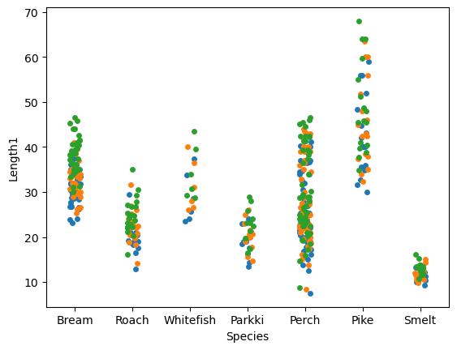

```python
sns.stripplot(y ='Length1', x = 'Species', data = df_fish)
sns.stripplot(y ='Length2', x = 'Species', data = df_fish)
sns.stripplot(y ='Length3', x = 'Species', data = df_fish)
plt.show()
```

-> in the above graph we are comparing lengths of species by plotting them in same graph

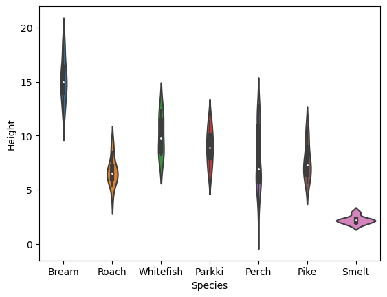

```python
sns.violinplot(x="Species", y="Height", data=df_fish, size=6)
plt.show()
```

->this violinplot gives how height points are scattered in a diagraphic way

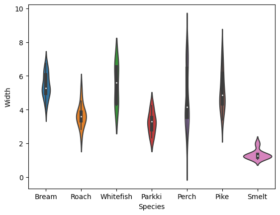

```python
sns.violinplot(x="Species", y="Width", data=df_fish, size=6)
plt.show()
```

[output not shown]

[output cut: 176 more lines]

[output not shown]

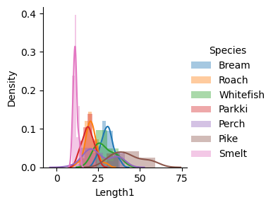

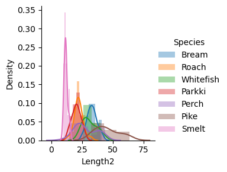

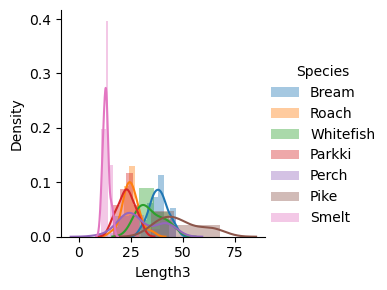

```python
plot = sns.FacetGrid(df_fish, hue="Species")
plot.map(sns.distplot, "Length1").add_legend()

plot = sns.FacetGrid(df_fish, hue="Species")
plot.map(sns.distplot, "Length2").add_legend()

plot = sns.FacetGrid(df_fish, hue="Species")
plot.map(sns.distplot, "Length3").add_legend()
plt.show()
```

-> The above plot gives different graph structures for same species to give contrast how each graph structure is visualized

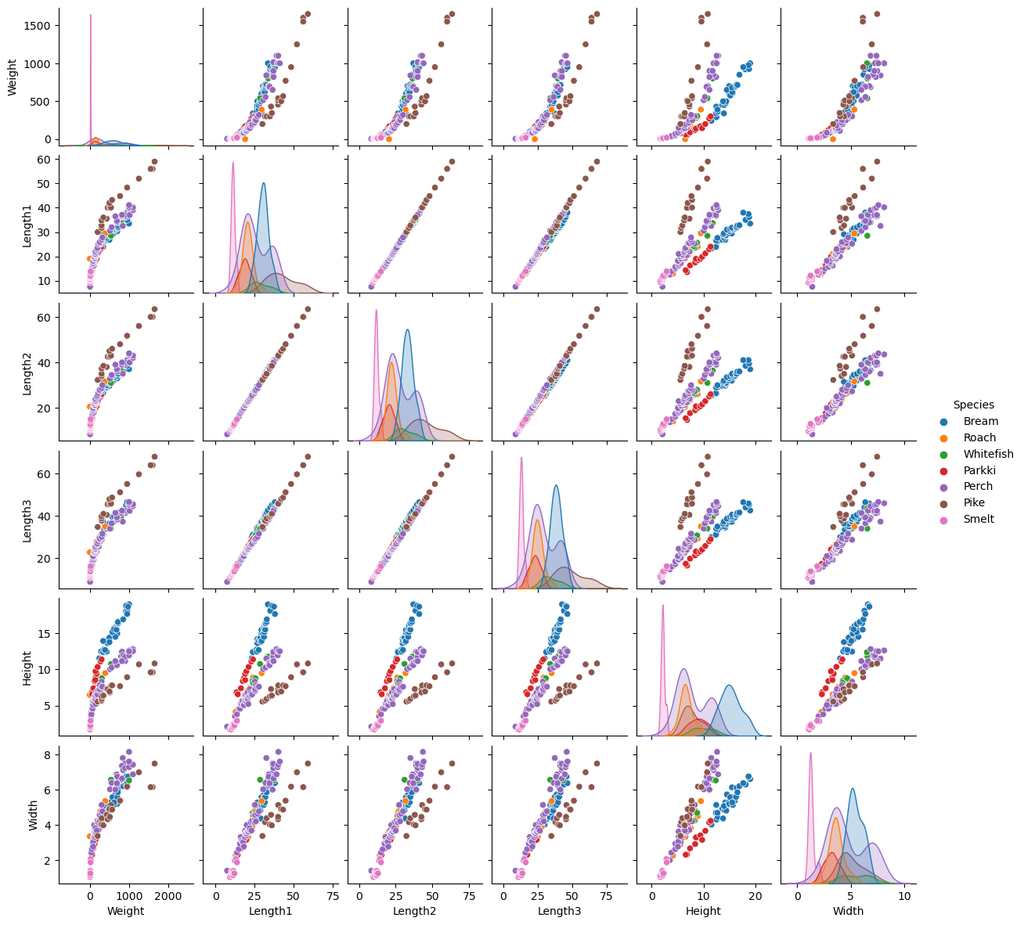

```python
sns.pairplot(data=df_fish,hue='Species', height=2)
```

->the pairplot compares two features of every kind and plot the graphs. these two features can be same some times

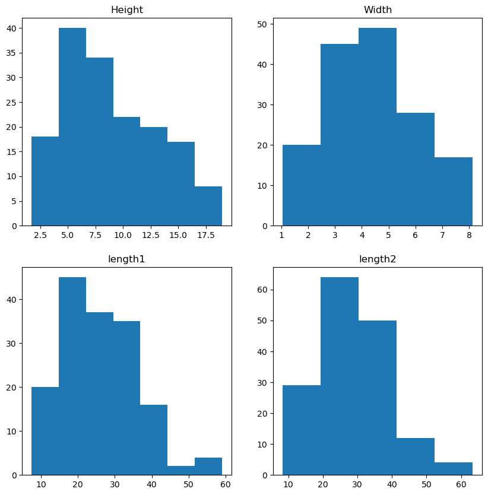

```python
fig, axes = plt.subplots(2, 2, figsize=(10,10))

axes[0,0].set_title("Height")
axes[0,0].hist(df_fish['Height'], bins=7)

axes[0,1].set_title("Width")
axes[0,1].hist(df_fish['Width'], bins=5)

axes[1,0].set_title("length1")
axes[1,0].hist(df_fish['Length1'], bins=7)

axes[1,1].set_title("length2")
axes[1,1].hist(df_fish['Length2'], bins=5)
```

->this plot is histogram plot of height,width and lengths

### 4. Identify significant correlations

```python
df_fish.corr(method='pearson')
```

|  | Weight | Length1 | Length2 | Length3 | Height | Width |
| --- | --- | --- | --- | --- | --- | --- |
| Weight | 1.000000 | 0.915712 | 0.918618 | 0.923044 | 0.724345 | 0.886507 |
| Length1 | 0.915712 | 1.000000 | 0.999517 | 0.992031 | 0.625378 | 0.867050 |
| Length2 | 0.918618 | 0.999517 | 1.000000 | 0.994103 | 0.640441 | 0.873547 |
| Length3 | 0.923044 | 0.992031 | 0.994103 | 1.000000 | 0.703409 | 0.878520 |
| Height | 0.724345 | 0.625378 | 0.640441 | 0.703409 | 1.000000 | 0.792881 |
| Width | 0.886507 | 0.867050 | 0.873547 | 0.878520 | 0.792881 | 1.000000 |

->correlation gives the linear relationship between variables.the correlation value nearer to 1 gives higher linear relationship and nearer to -1 is negative linear relationship, if 0 then no negative relationship

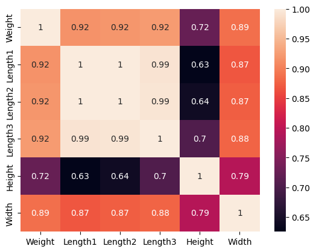

```python
sns.heatmap(df_fish.corr(method='pearson'),
            annot = True);

plt.show()
```

**Your Answer:**</strong>

-> the values (length1,length2) have perfect linear relationship,(length3,length1),(length3,length2) have nearly perfect linear relationship and (length1,height) and (length2,height) have least correlation value

### 5. Spot outliers and what to do with them?

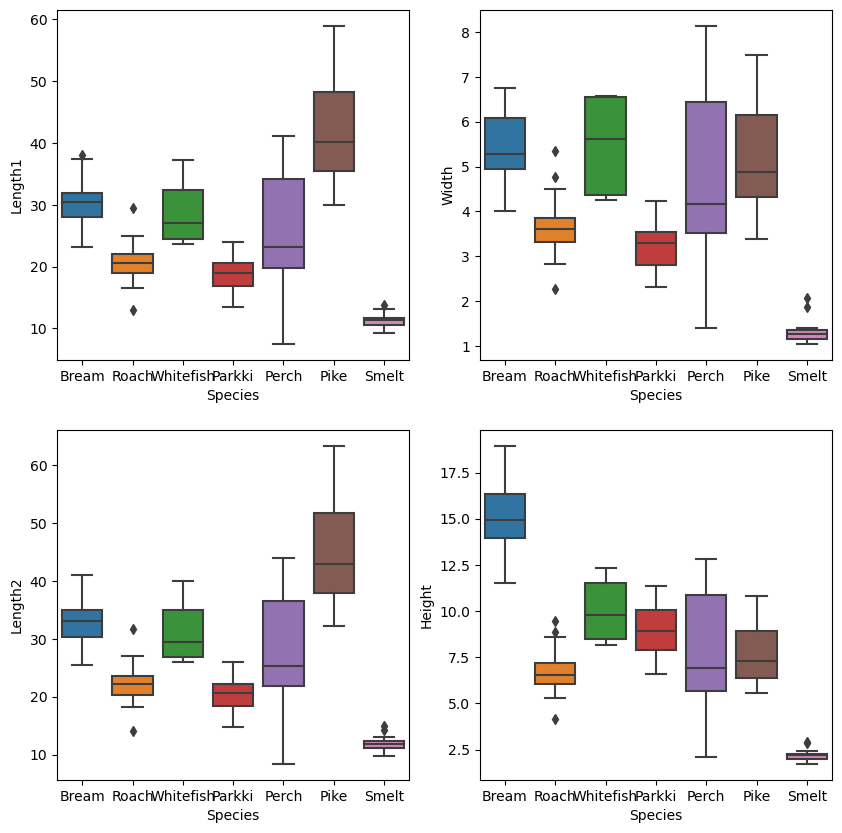

```python
def graph(y):
    sns.boxplot(x="Species", y=y, data=df_fish)

plt.figure(figsize=(10,10))

# Adding the subplot at the specified
# grid position
plt.subplot(221)
graph('Length1')

plt.subplot(222)
graph('Width')

plt.subplot(223)
graph('Length2')

plt.subplot(224)
graph('Height')

plt.show()
```

this is box plot which gives outliers and range of data

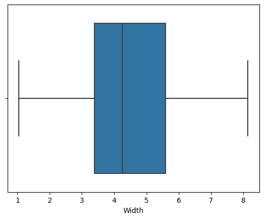

```python
sns.boxplot(x='Width', data=df_fish)
```

the width feature have no outlier

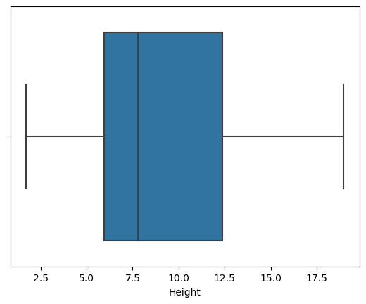

```python
sns.boxplot(x='Height', data=df_fish)
```

the height have no outliers

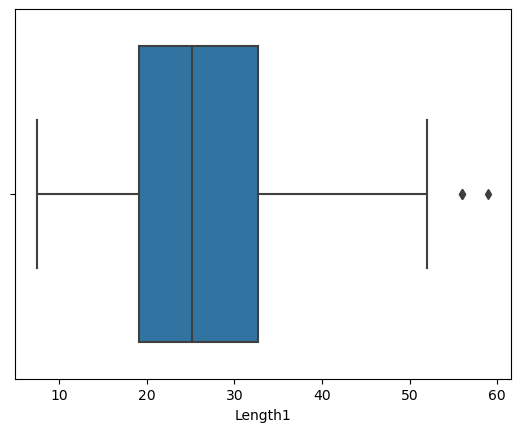

```python
sns.boxplot(x='Length1', data=df_fish)
```

the length1 have 2 outliers

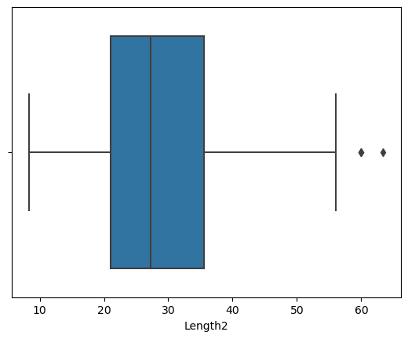

```python
sns.boxplot(x='Length2', data=df_fish)
```

the length2 have 2 outliers

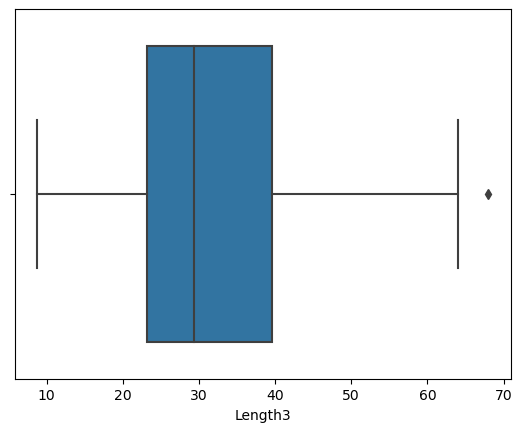

```python
sns.boxplot(x='Length3', data=df_fish)
```

the length3 have 1 outliers

[output not shown]

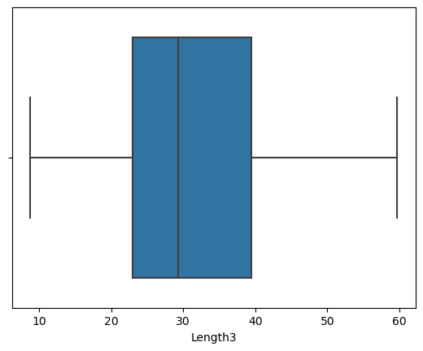

```python
Q1 = np.percentile(df_fish['Length3'], 25,
                interpolation = 'midpoint')

Q3 = np.percentile(df_fish['Length3'], 75,
                interpolation = 'midpoint')
IQR = Q3 - Q1

print("Old Shape: ", df_fish.shape)

# Upper bound
upper = np.where(df_fish['Length3'] >= (Q3+1.5*IQR))

# Lower bound
lower = np.where(df_fish['Length3'] <= (Q1-1.5*IQR))

# Removing the Outliers
df_fish.drop(upper[0], inplace = True)
df_fish.drop(lower[0], inplace = True)

print("New Shape: ", df_fish.shape)

sns.boxplot(x='Length3', data=df_fish)
```

**Your Answer:**</strong>

the above is the code to remove outlier if we have outlier either we try to merge the outlier with data,if the data is important and the outliers are more. if not we can totally remove outlier and work on data for what we want.

**Summary**</strong>

-> the fish data exploitary data analysis(EDA) gives basic understanding of data of what we have and what are the things we have to look for while performing an operation. ->it also helps in easy representation of data as well as visualization of data, so that we easily explain and understand what is happening with data and its features -> it also helps in finding correlation with each feature and how each feature or column value effect the whole data set ->if data is hard to work with we can modify it with finding,removing or merging outliers and filling empty spaces with appropriate value as well as removing wrong data and adding correct data etc -> EDA is really helpful in finding which classification or regression technique is used for certain data and EDA is useful for companies to processes and make data efficient to work with. -> this is my understanding of EDA.